# 2018 Model Extension

Sean Davern

June 15, 2019

# Overview

This notebook extends the modeling done in 2013 to include data through much of 2018.

# Load Data

Loading cleaned and transformed giving data:

```r
df <- readRDS("../data/Cleaned and Transformed Giving Data.rds")
head(df)
```

|  | week.ending | month | year | total | monthly.giving.families | SundaysInMonth | MonthsGivingPerWeek |
| --- | --- | --- | --- | --- | --- | --- | --- |
| 1 | 2010-01-31 | January | 2010 | 14241.15 | 45 | 5 | 2848.230 |
| 2 | 2010-02-28 | February | 2010 | 22437.50 | 41 | 4 | 5609.375 |
| 3 | 2010-03-28 | March | 2010 | 13317.00 | 32 | 4 | 3329.250 |
| 4 | 2010-04-25 | April | 2010 | 13232.50 | 36 | 4 | 3308.125 |
| 5 | 2010-05-30 | May | 2010 | 13478.15 | 40 | 5 | 2695.630 |
| 6 | 2010-06-27 | June | 2010 | 14930.50 | 43 | 4 | 3732.625 |

# Columns to Accomodate Analysis

I’ll add a few columns to enable asking analysis “what if’s” and adjust for anomolies:

```r
library("dplyr", quietly=TRUE, warn.conflicts = FALSE)
df <- mutate(df,
             excluded = FALSE,
             removed.amount = 0,
             original.total = total)
```

# Accommodating Unusual Gift

```r
df$removed.amount[as.Date(df$week.ending) == "2016-12-25"] <- 20000
df$total <- df$original.total - df$removed.amount
#df$excluded[as.Date(df$week.ending) == "2016-12-25"] <- TRUE
```

Note: we’re not excluding the 3 months consider “outliers” in the 2013 analysis. Now with 9 years of history, those months don’t appear as much to be outliers.

# Modeling

Regressing the R version of the 2013 model:
$$\textit{Monthly Giving} = a+b_{year}+c_{month}$$

```r
mod <- lm(
  formula = total ~
    year + month,
  data = df[df$excluded!=TRUE,]
)
```

…gives the following

# Model Predictions

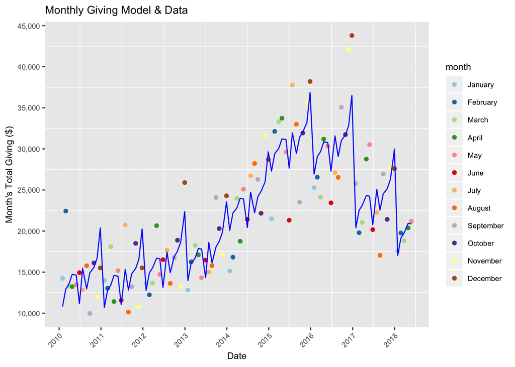

In this case it is far more clear that giving was increasing through 2016 which would be expected to improve the statistical significance of the $year$ model term over what was seen in the 2013 analysis.

# Model Fit Assessment

|  | Df | Sum Sq | Mean Sq | F value | Pr(>F) |
| --- | --- | --- | --- | --- | --- |
| year | 8 | 3920266253 | 490033282 | 30.197577 | 2.718968e-21 |
| month | 11 | 588525930 | 53502357 | 3.297004 | 8.960459e-04 |
| Residuals | 81 | 1314433124 | 16227569 | NA | NA |

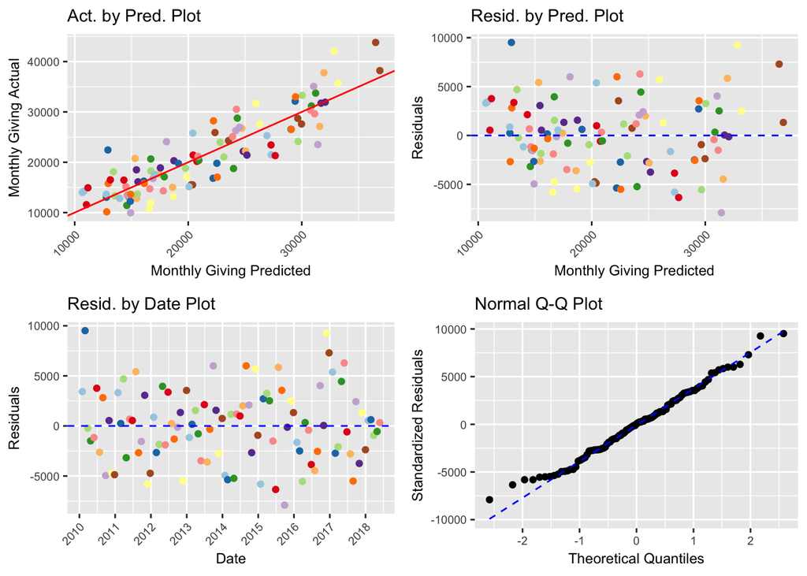

Both model terms are highly statistically significant. The residuals seem nicely randomly scattered. I don’t see any particularly concerning patterns in the plots including model biases by month (dot color). The quantile plot shows very normally distributed residuals.

# Regressed Model Details

```
##
## Call:
## lm(formula = total ~ year + month, data = df[df$excluded != TRUE,
##     ])
##
## Residuals:
##     Min      1Q  Median      3Q     Max
## -7904.4 -2659.0    46.1  2486.6  9513.2
##
## Coefficients:
##                Estimate Std. Error t value Pr(>|t|)
## (Intercept)     10807.3     1741.1   6.207 2.18e-08 ***
## year2011         -133.7     1644.6  -0.081  0.93542
## year2012         1974.0     1644.6   1.200  0.23352
## year2013         3165.1     1644.6   1.925  0.05779 .
## year2014         9265.5     1644.6   5.634 2.47e-07 ***
## year2015        16494.5     1644.6  10.030 7.42e-16 ***
## year2016        16124.2     1644.6   9.805 2.05e-15 ***
## year2017         9597.9     1644.6   5.836 1.06e-07 ***
## year2018         6215.8     2198.7   2.827  0.00592 **
## monthFebruary    2117.0     1899.0   1.115  0.26824
## monthMarch       2739.3     1899.0   1.443  0.15301
## monthApril       3918.4     1899.0   2.063  0.04227 *
## monthMay         3833.6     1899.0   2.019  0.04682 *
## monthJune         359.5     1968.9   0.183  0.85559
## monthJuly        4648.5     1968.9   2.361  0.02063 *
## monthAugust      2149.1     1968.9   1.092  0.27828
## monthSeptember   4115.6     1968.9   2.090  0.03973 *
## monthOctober     4765.5     1968.9   2.420  0.01774 *
## monthNovember    5895.7     1968.9   2.994  0.00365 **
## monthDecember    9574.9     1968.9   4.863 5.59e-06 ***
## ---
## Signif. codes:  0 '***' 0.001 '**' 0.01 '*' 0.05 '.' 0.1 ' ' 1
##
## Residual standard error: 4028 on 81 degrees of freedom
## Multiple R-squared:  0.7743, Adjusted R-squared:  0.7213
## F-statistic: 14.62 on 19 and 81 DF,  p-value: < 2.2e-16
```

# Model Generalization

Due to R’s conventions, the model coefficients, as regressed by R:
$$\textit{Monthly Giving} = a+b_{year}+c_{month}$$
are regressed relative to $month_1$=January ($c_{January}=0$) and $year_1$=2010 ($b_{2010}=0$). This is why there is no year2010 nor monthJanuary coeffiencients. A more useful set of references for forecasting would be “an average month” and “an average year”. Thus we can modify the model as such:
$$\begin{aligned}
\begin{split}
\textit{Monthly Giving}
&= a+(\overline{b_{year}}+b_{year}-\overline{b_{year}})+
(\overline{c_{month}}+c_{month}-\overline{c_{month}})
\\
&= \big[a+\overline{b_{year}}+\overline{c_{month}}\big]+
\big(b_{year}-\overline{b_{year}}\big)+
\big(c_{month}-\overline{c_{month}}\big)
\end{split}
\end{aligned}$$
where $\overline{b_{year}}$ is the mean of $b_{year}$ coefficients, including $b_{2010}=0$, and $\overline{c_{month}}$ is the mean of the $c_{year}$ coefficients, including $c_{January}=0$. The term $\big[a+\overline{b_{year}}+\overline{c_{month}}\big]$ is then the regressed $\textit{Monthly Giving}$ for an average month in an average year over the period covered by the data. Of course no actual month or year is the average, and to reproduce a given month and year prediction the shifted coefficients $(b_{year}-\overline{b_{year}}) \text{ and } (c_{month}-\overline{c_{month}})$ must be employed. However, this facilitates using the model for monthly variance predictions in the upcoming year since:
$$\begin{aligned}
\begin{split}
\textit{Average Monthly Giving}_\textit{next year}
&=\big[a+\overline{b_{year}}+\overline{c_{month}}\big]+\big(b_\textit{next year}-\overline{b_{year}}\big)
\\
&=\frac{\textit{Projected Income}_\textit{next year}}{12}
\end{split}
\end{aligned}$$
So even though we don’t know $b_\textit{next year}$ we can make an estimation for next year’s total $\textit{Projected Income}$ and get monthly estimates based on the annual estimate:

$$\textit{Monthly Giving}_\textit{next year}
=\frac{\textit{Projected Income}_\textit{next year}}{12} +
\big(c_{month}-\overline{c_{month}}\big)$$

# Monthly Variation

This plot shows the resulting $month$ regression coeffiecients shifted by $\overline{c_{month}}$ capturing month-to-month variation. ($(c_{month}-\overline{c_{month}})$) The shape of the yearly repeated pattern in the prediction are the result of these terms.

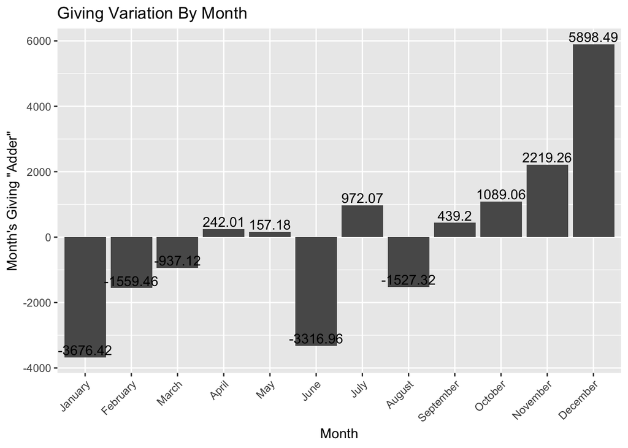

This plot is generally similar to Figure 13 in the 2013 Analysis with the exception of November. Since it is based on 9 years of Seed history, I’ll judge that it is more representative of an average year.